# R Notebook sandbox: Playing with PCA

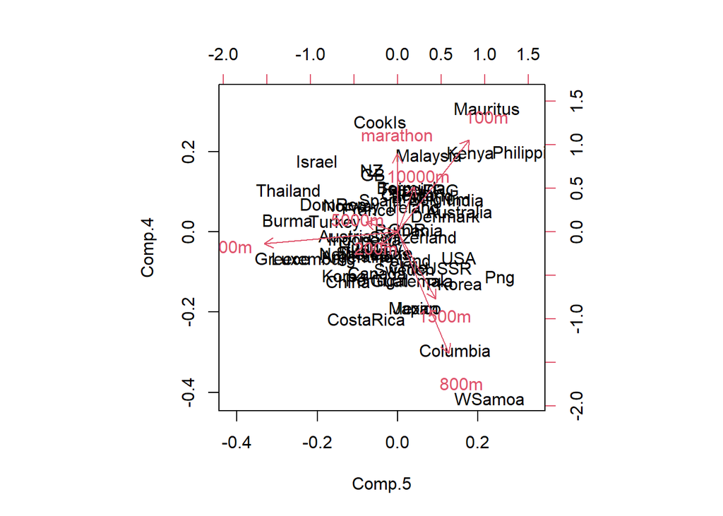

```r
biplot(Xs.princomp, 5:4);  # Cook & marathon, Mauritius and 100m, W. Samoa and 800m
```

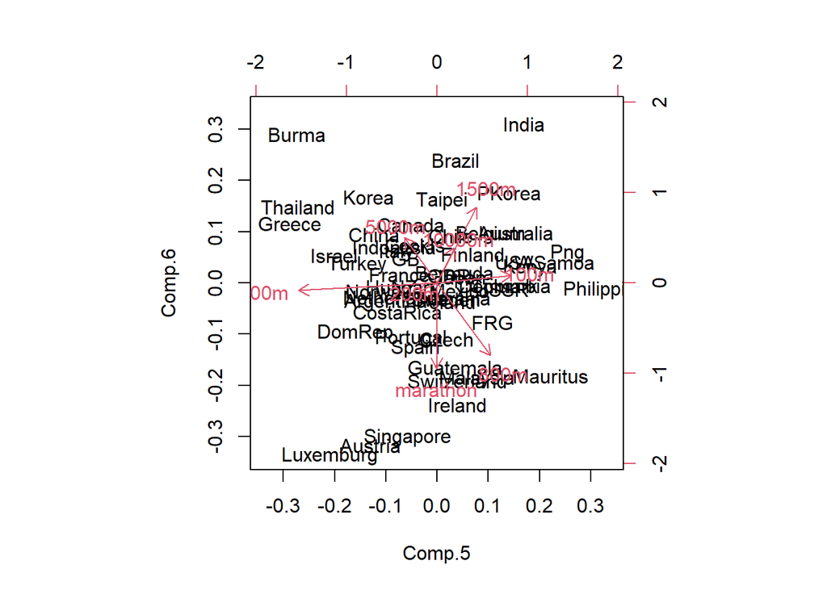

```r
biplot(Xs.princomp, 5:6);
```

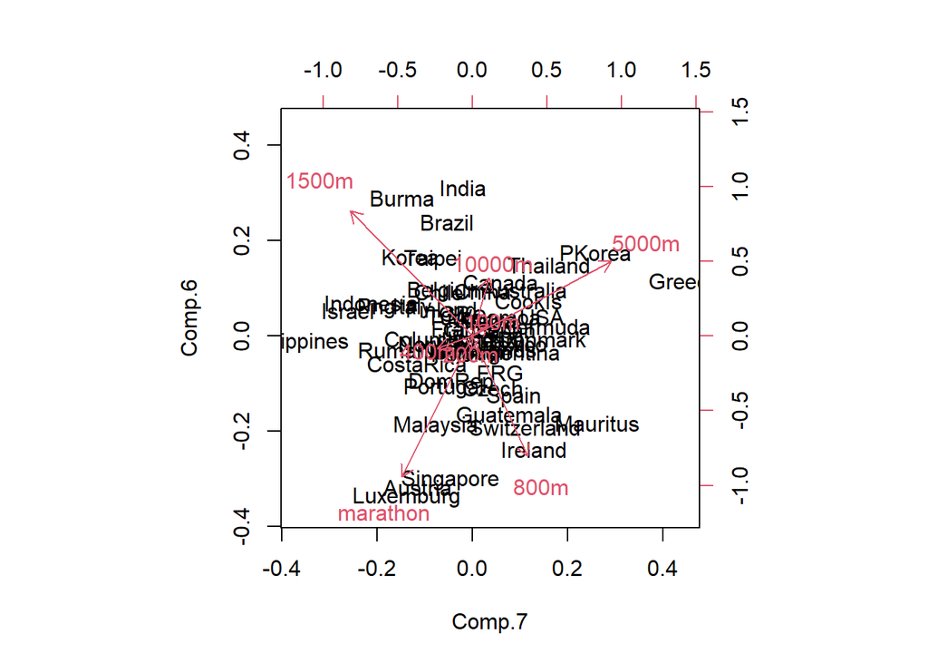

```r
biplot(Xs.princomp, 7:6);
```

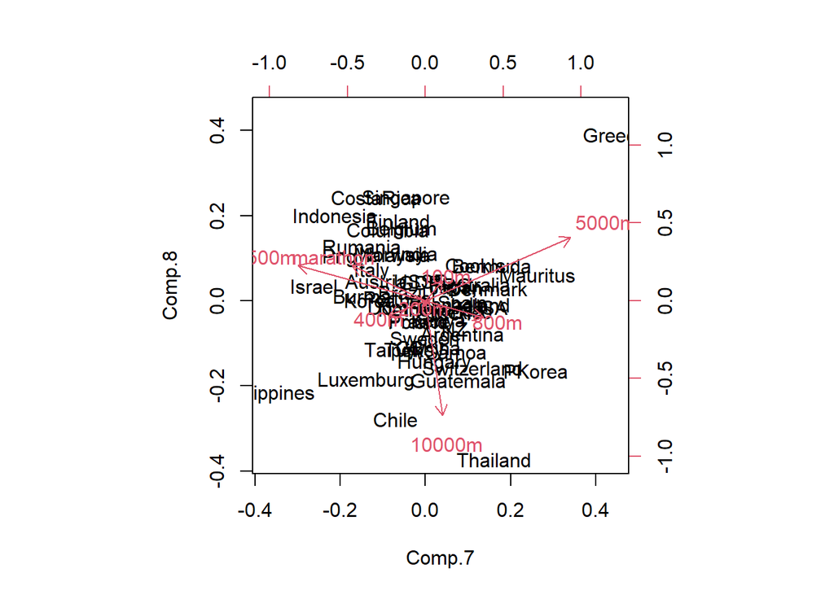

```r
biplot(Xs.princomp, 7:8);
```

```r
# notice the ordering
# the next will have the same component on the same dimension

# There are meaning in the higher dimensions, although it does not explain a lot of variance in all of the Countries, it may represent a specific athlete:

# Netherlands   200m
# Cook          marathon
# Mauritius     100m
# W. Samoa      800m
```

Think about what this is showing. It is mapping **both** the rows (countries) and columns (races) on the same component reduction map (showing any two components at a time).

# 4 Conclusion

https://en.wikipedia.org/wiki/200_metres#Men_(outdoor)

Who the outliers from these countries may be very difficult to discover because the Soviet era doesn’t seem to have a lot of balanced records.

https://en.wikipedia.org/wiki/Men%27s_200_metres_world_record_progression

Maybe Muriaroa Ngaro (1980) was the runner associated with the marathon from the Cook Islands https://en.wikipedia.org/wiki/List_of_Cook_Islands_records_in_athletics#Men

In 1980, he ran the marathon in 2:51:26 … The winning time was 2:11:03 run by German Waldemar Cierpinski (East Germany). https://en.wikipedia.org/wiki/Athletics_at_the_1980_Summer_Olympics_%E2%80%93_Men%27s_marathon

So maybe Muriaroa Ngaro was an extreme outlier because he was so slow.

```r
X[c(12,34,36,38,51,55,53,54),];
```

|  | 100m | 200m | 400m | 800m | 1500m | 5000m | 10000m | marathon |
| --- | --- | --- | --- | --- | --- | --- | --- | --- |
| CookIs | 12.18 | 23.20 | 52.94 | 2.02 | 4.24 | 16.70 | 35.38 | 164.70 |
| Luxemburg | 10.35 | 20.77 | 47.40 | 1.82 | 3.67 | 13.64 | 29.08 | 141.27 |
| Mauritus | 11.19 | 22.45 | 47.70 | 1.88 | 3.83 | 15.06 | 31.77 | 152.23 |
| Netherlands | 10.52 | 29.95 | 45.10 | 1.74 | 3.62 | 13.36 | 27.61 | 129.02 |
| Thailand | 10.39 | 21.09 | 47.91 | 1.83 | 3.84 | 15.23 | 32.56 | 149.90 |
| WSamoa | 10.82 | 21.86 | 49.00 | 2.02 | 4.24 | 16.28 | 34.71 | 161.83 |
| USA | 9.93 | 19.75 | 43.86 | 1.73 | 3.53 | 13.20 | 27.43 | 128.22 |
| USSR | 10.07 | 20.00 | 44.60 | 1.75 | 3.59 | 13.20 | 27.53 | 130.55 |

```r
source_url( paste0(path.github, "humanVerseWSU/R/functions-stats.R") );  # updated findOutliersUsingIQR
```

```
## SHA-1 hash of file is 239423ccffb768d1fe2d2b9adf3b03ec5bd43628
```

```r
## so let's examine
Countries = rownames(X);
Events = colnames(X);

for(i in 1:8)
  {
  event = Events[i];
  print("############################");
  print(paste0( " Event :: ", event ) );  # print(paste0 ... should be a helper function ... use it all the time
  print("############################");

  outliers = findOutliersUsingIQR(X[,i]);
    very.slow = outliers$outer.upper;  # outer fence ...
    slow = setdiff(outliers$inner.upper, very.slow);  # "unique" inner fence ...

    very.fast = outliers$outer.lower;  # outer fence ...
    fast = setdiff(outliers$inner.lower,very.fast);  # inner fence ...


  if(length(very.slow) > 0)
    {
    print("-------------- very.slow --------------");
    print( Countries[ very.slow ] );
    print("---------------------------------------");
    }
  if(length(slow) > 0)
    {
    print("---------------- slow -----------------");
    print( Countries[ slow ] );
    print("---------------------------------------");
    }


  if(length(fast) > 0)
    {
    print("---------------- fast -----------------");
    print( Countries[ fast ] );
    print("---------------------------------------");
    }

  if(length(very.fast) > 0)
    {
    print("-------------- very.fast --------------");
    print( Countries[ very.fast ] );
    print("---------------------------------------");
    }



  }
```

```
## [1] "############################"
## [1] " Event :: 100m"
## [1] "############################"
## [1] "-------------- very.slow --------------"
## [1] "CookIs"
## [1] "---------------------------------------"
## [1] "---------------- slow -----------------"
## [1] "Mauritus"
## [1] "---------------------------------------"
## [1] "############################"
## [1] " Event :: 200m"
## [1] "############################"
## [1] "-------------- very.slow --------------"
## [1] "Netherlands"
## [1] "---------------------------------------"
```

[output cut: 42 more lines]

## 4.1 Another EDA analysis: hclust/pvclust

### 4.1.1 Xs.hclust.8

```r
source_url( paste0(path.github, "humanVerseWSU/R/functions-EDA.R") );
```

```
## SHA-1 hash of file is 6bd5154c16ec52b82f168904395cc551799c0c7f
```

```r
# Xs;
dim(Xs);
```

```
## [1] 55  8
```

```r
Xs.hclust.8 = perform.hclust(Xs, n.groups = 8, pvclust.parallel = TRUE);
```

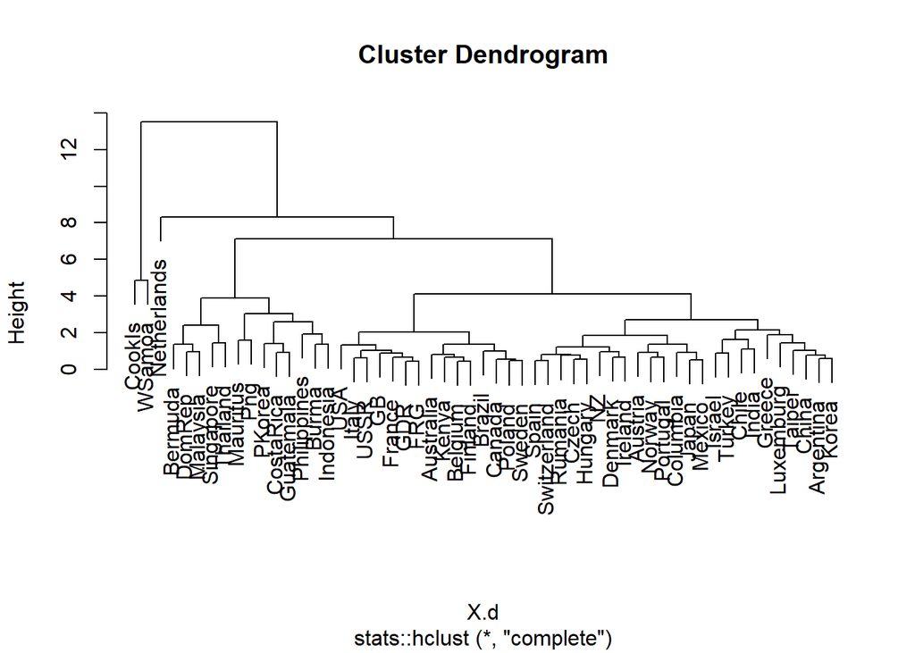

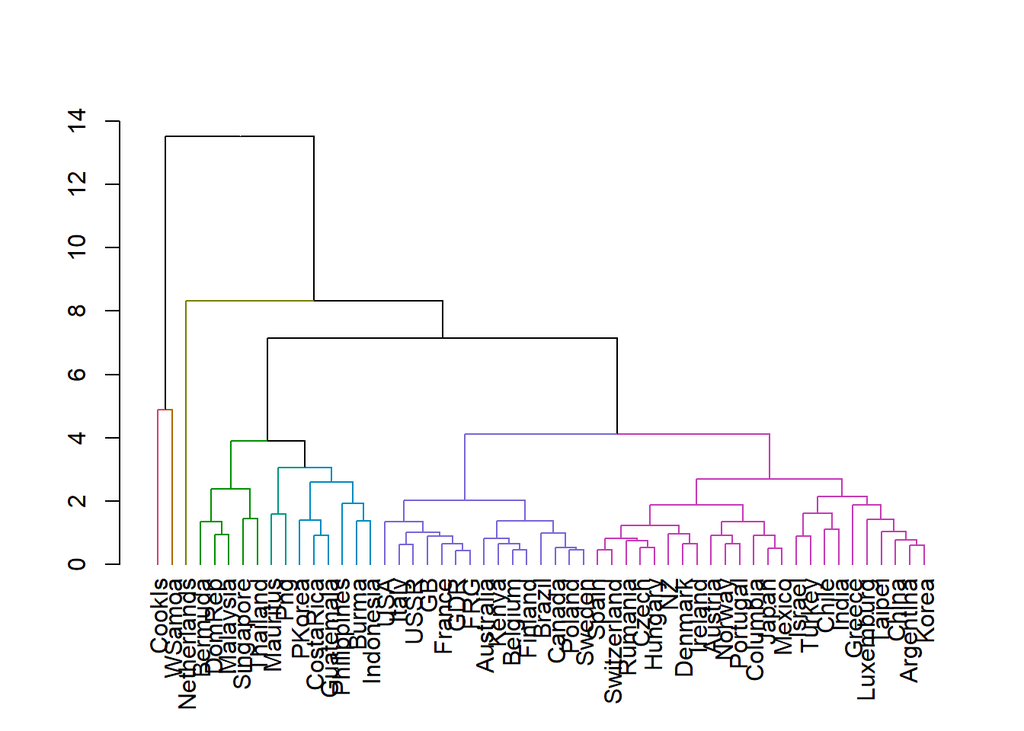

```
## [1] "Pruning 1 of 8"
## [1] "Pruning 2 of 8"
## [1] "Pruning 3 of 8"
## [1] "Pruning 4 of 8"
## [1] "Pruning 5 of 8"
## [1] "Pruning 6 of 8"
## [1] "Pruning 7 of 8"
## [1] "Pruning 8 of 8"
```

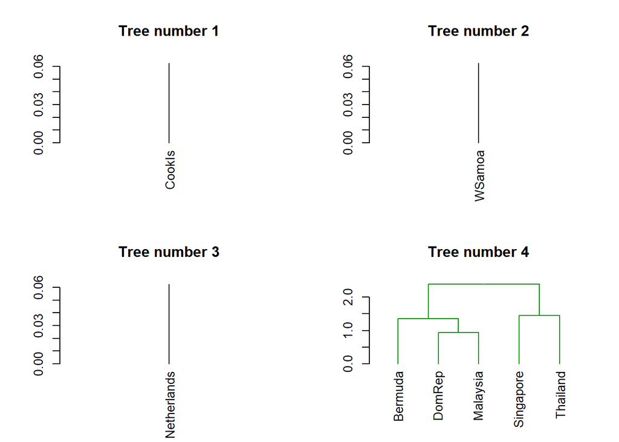

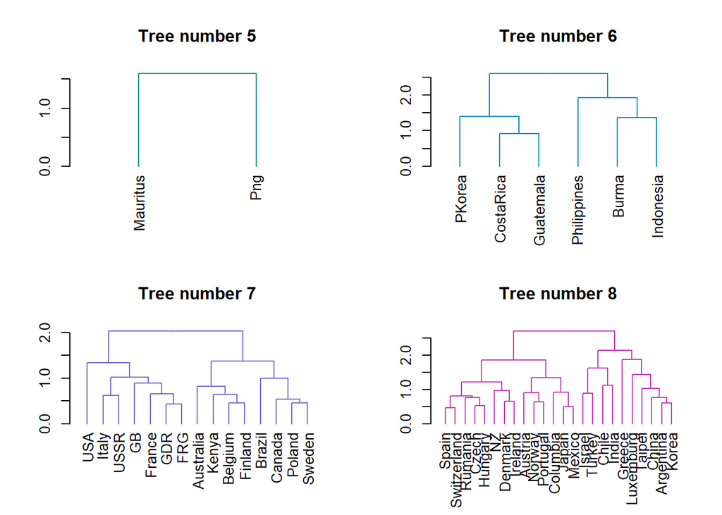

```
## Creating a temporary cluster...done:
## socket cluster with 15 nodes on host 'localhost'
## Multiscale bootstrap... Done.
```

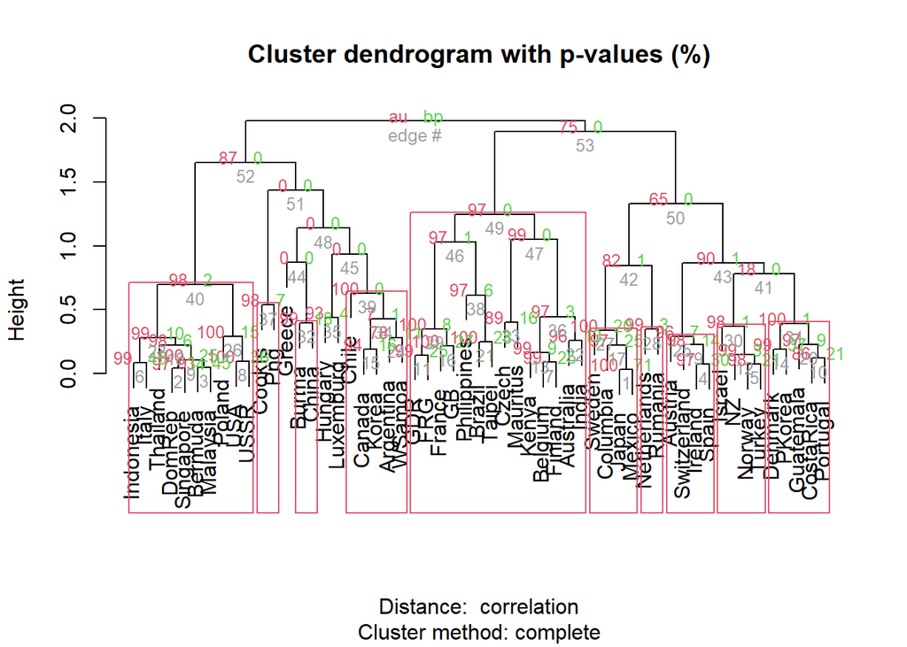

```r
# if this doesn't work, turn off parallel ... # pvclust.parallel = FALSE

# if TRUE, (parallel::detectCores() - 1)
# you can pass a number like "ncores"
# pvclust.parallel = 4
```

### 4.1.2 Xs.t.hclust.6

```r
Xs.t = transposeMatrix(Xs);
#Xs.t;
dim(Xs.t);
```

```
## [1]  8 55
```

```r
Xs.t.hclust.6 = perform.hclust(Xs.t, n.groups = 6, pvclust.parallel = TRUE);
```

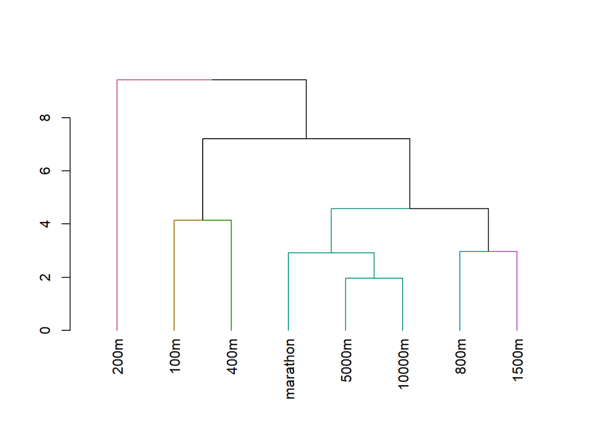

```
## [1] "Pruning 1 of 6"
## [1] "Pruning 2 of 6"
## [1] "Pruning 3 of 6"
## [1] "Pruning 4 of 6"
## [1] "Pruning 5 of 6"
## [1] "Pruning 6 of 6"
```

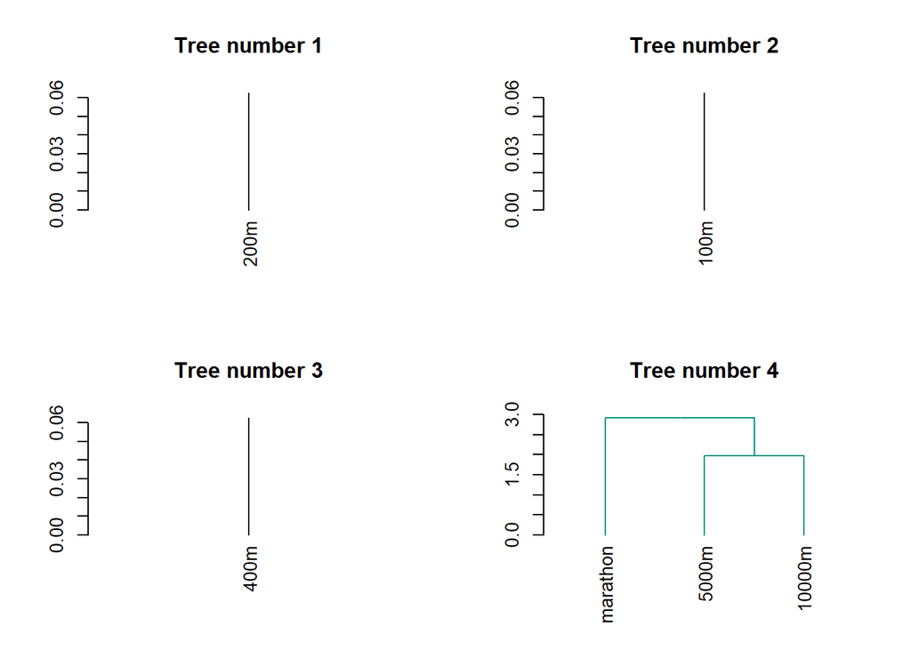

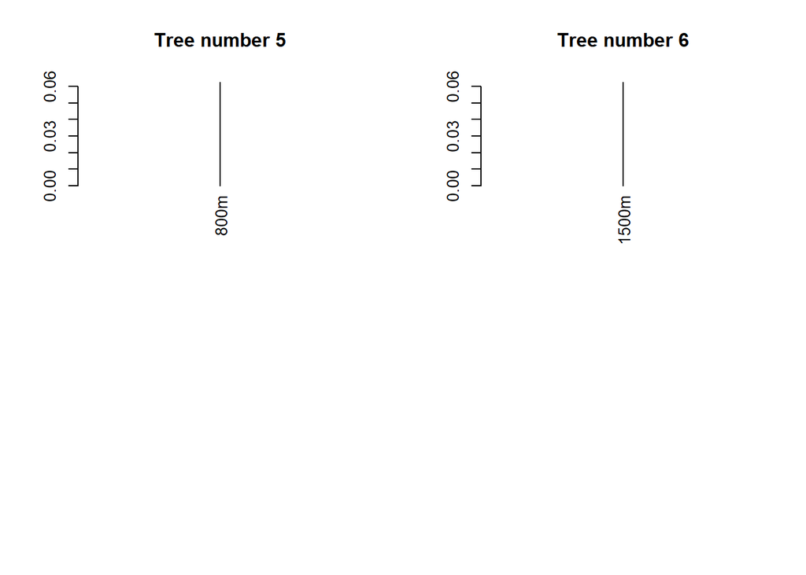

```
## Creating a temporary cluster...done:
## socket cluster with 15 nodes on host 'localhost'
## Multiscale bootstrap... Done.
```

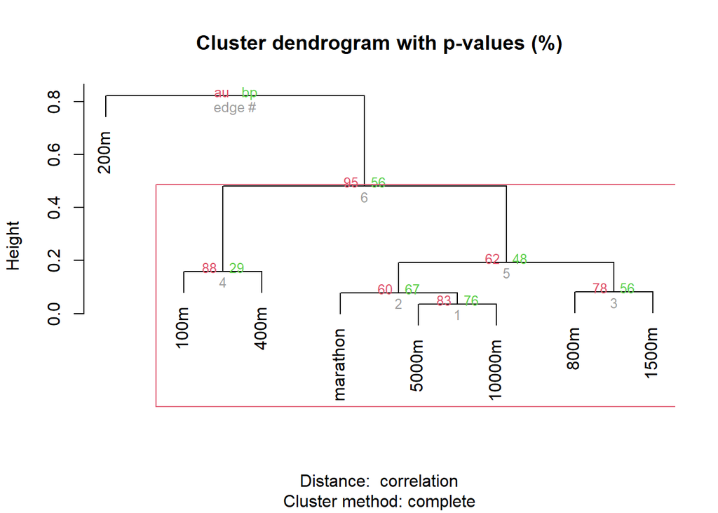

### 4.1.3 Xs.t.hclust.4

```r
Xs.t.hclust.4 = perform.hclust(Xs.t, n.groups = 4, pvclust.parallel = TRUE);
```

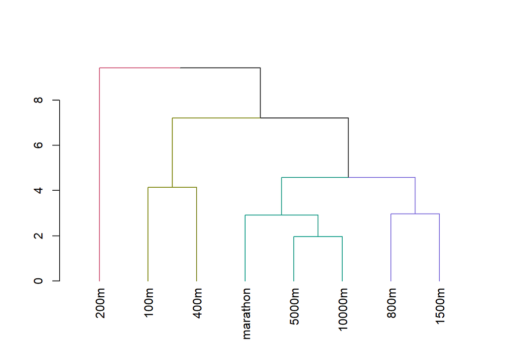

```
## [1] "Pruning 1 of 4"
## [1] "Pruning 2 of 4"
## [1] "Pruning 3 of 4"
## [1] "Pruning 4 of 4"
```

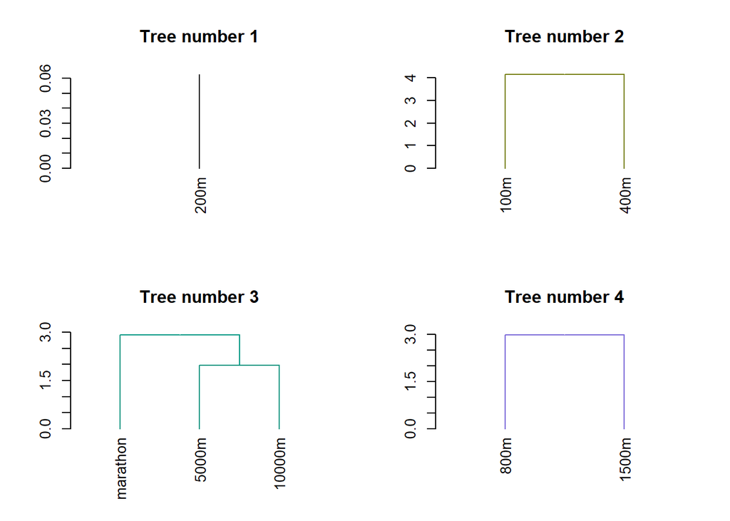

```
## Creating a temporary cluster...done:
## socket cluster with 15 nodes on host 'localhost'
## Multiscale bootstrap... Done.
```

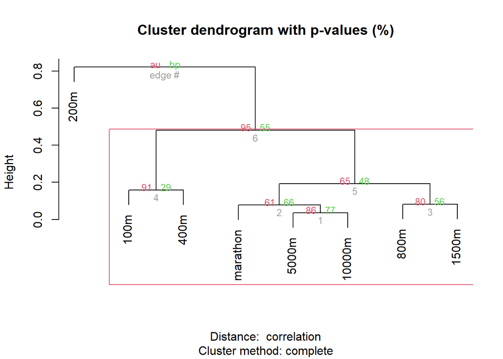

### 4.1.4 Xs.t.hclust.2

```r
Xs.t.hclust.2 = perform.hclust(Xs.t, n.groups = 2, pvclust.parallel = TRUE);
```

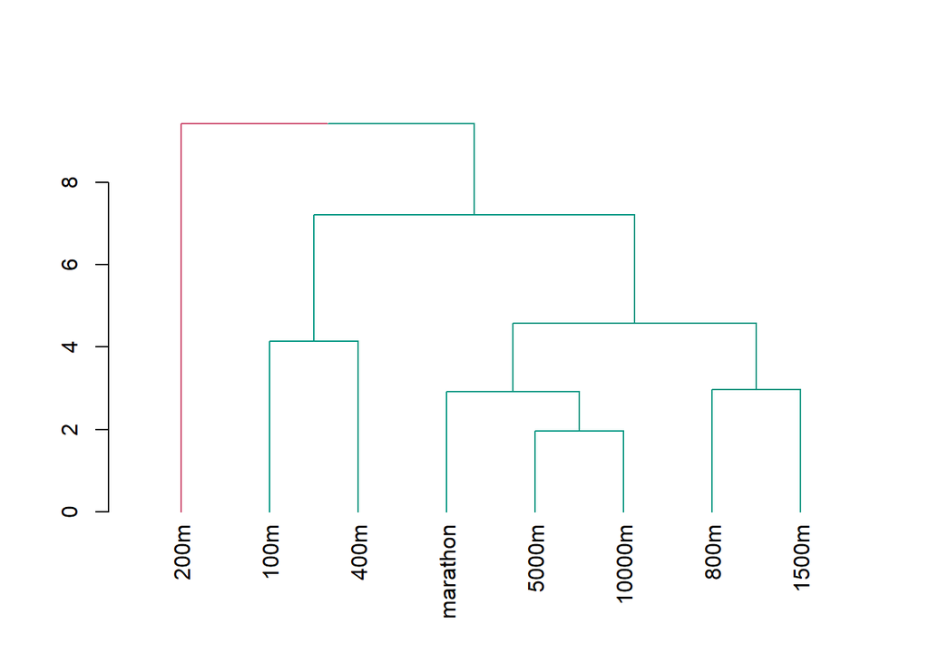

```
## [1] "Pruning 1 of 2"
## [1] "Pruning 2 of 2"
```

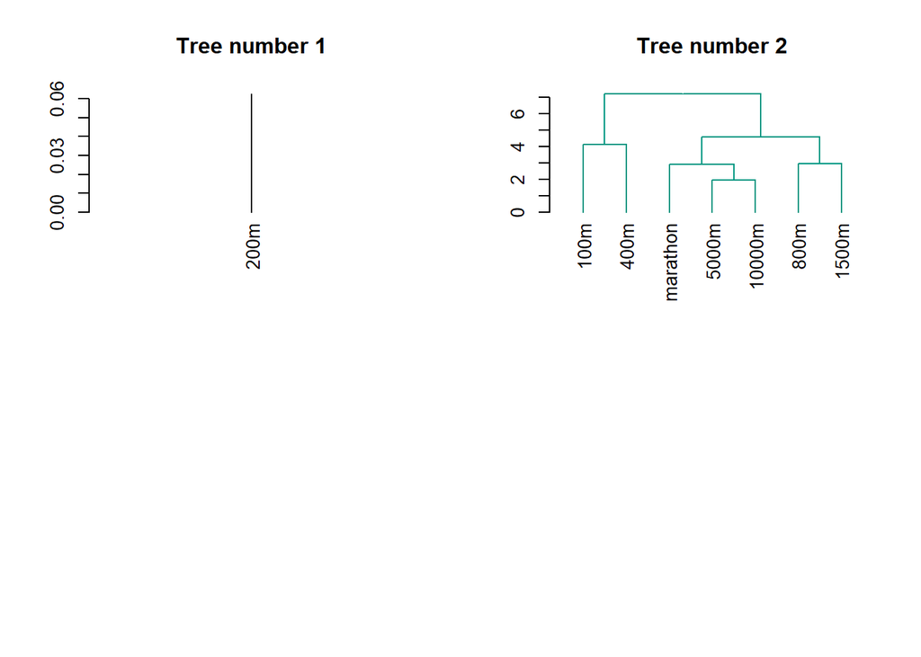

```
## Creating a temporary cluster...done:
## socket cluster with 15 nodes on host 'localhost'
## Multiscale bootstrap... Done.
```

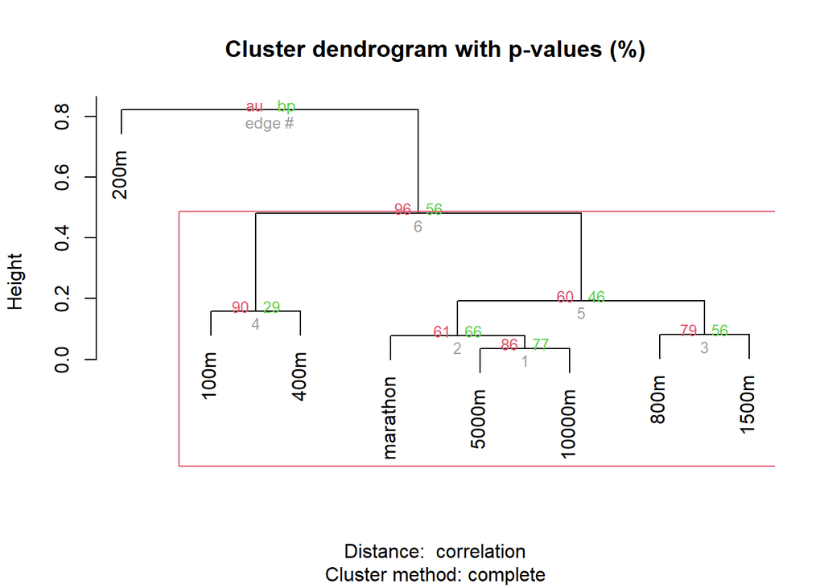